# P&S-2022: Lab assignment 2

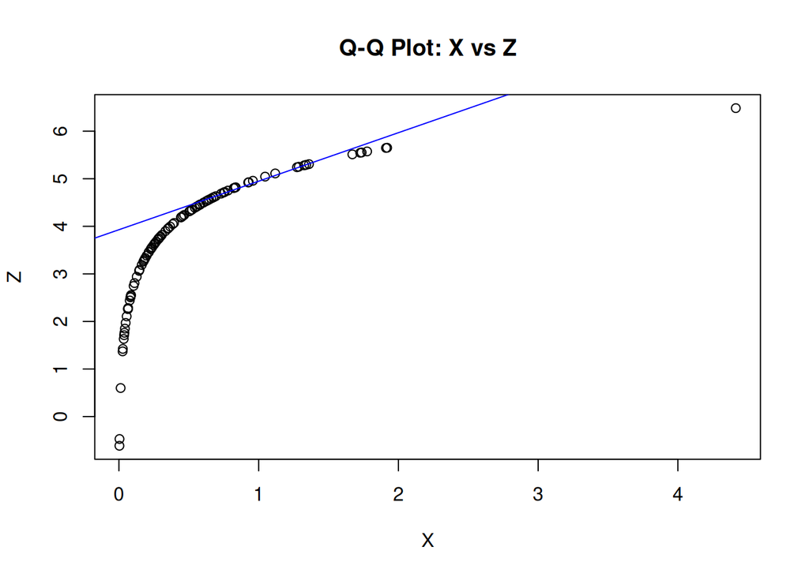

```r
# Here we can see chaotic number of points. We don't have any pattern here so X and Y are independent.

qqplot(X_exp, Z_exp,
       main = "Q-Q Plot: X vs Z",
       xlab = "X", ylab = "Z")
# Adding line for y=x.
qqline(Z_exp, col = "blue")
```

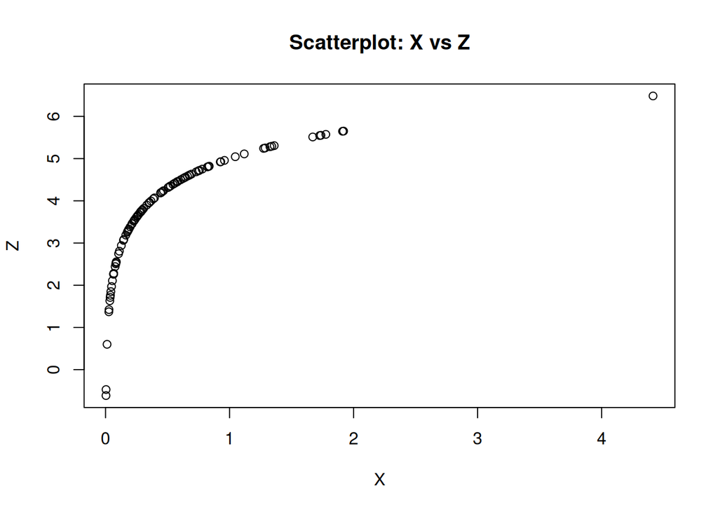

```r
# The points form a curve and do not lie on the line. Therefore, X and Z are NOT "similar" (they are from different distributions).

plot(X_exp, Z_exp,
     main = "Scatterplot: X vs Z",
     xlab = "X", ylab = "Z")
```

```r
# Here we can see a clear logarithmic curve. All points lie on it. This proves that Z is functionally dependent on X.
```

The (X, Z) pair is dependent. “Dependent” means the value of one variable gives you information about the other. We created $Z$ from $X$ using the formula $Z = \log(X) + 5$. Because $Z$ is calculated directly from $X$, they are functionally dependent. Our scatterplot confirms this, showing all points perfectly aligned on a logarithmic curve.

```
------------------------------------------------------------------------
```

2. You toss a fair coin three times and a random variable $X$ records how many times the coin shows Heads. You convince your friend that they should play a game with the following payoff: every round (equivalent to three coin tosses) will cost £$1$. They will receive £$0.5$ for every coin showing Heads. What is the expected value and the variance of the random variable $Y := 0.5X-1$?

   To answer this,
   1. Explain what type of random variable is X:

      X - is the number of Heads in three tosses, in other words it is the number of successes, so X∼Binomial(n=3,p=0.5)
   2. What are the expected value and variance of X? Simulate realizations $x_1,x_2,\dots,x_{100}$ of $X$ to calculate the values of sample mean $\overline{\mathbf{X}}$ and sample variance $s^2 = \frac{\sum_{i=1}^{n}{(x_i - \overline{x})^{2}}}{n-1}$. Comment on the results;

```r
theoretical_mean_X <- 1.5        #E[X]=np=3*0.5
theoretical_var_X <- 0.75        #Var(X)=np(1−p)=3*0.5*0.5

n <- 100
sample_X <- rbinom(n, 3, 0.5)

sample_mean_X <- mean(sample_X)
sample_var_X <- var(sample_X)

results <- data.frame(means = c(theoretical_mean_X, sample_mean_X),
                      variances = c(theoretical_var_X, sample_var_X))

results
```

| means | variances |
| --- | --- |
| 1.50 | 0.7500000 |
| 1.62 | 0.5612121 |

The sample mean and sample variance computed from 100 simulated values is close to the theoretical E[X]=1.5 and Var(X)=0.75. As the number of simulations increases, the sample mean will converge to the theoretical mean (Law of Large Numbers).

3. What are the expected value and variance of Y? Simulate realizations $y_1,y_2,\dots,y_{100}$ of $Y$ to calculate the values of sample mean $\overline{\mathbf{Y}}$ and sample variance $s^2 = \frac{\sum_{i=1}^{n}{(y_i - \overline{y})^{2}}}{n-1}$. Comment on the results;

```r
sample_Y <- 0.5 * sample_X - 1

theoretical_mean_Y <- 0.5*theoretical_mean_X - 1
theoretical_var_Y  <- 0.5^2*theoretical_var_X

sample_mean_Y <- mean(sample_Y)
sample_var_Y <- var(sample_Y)

results <- data.frame(means = c(theoretical_mean_Y, sample_mean_Y),
                      variances = c(theoretical_var_Y, sample_var_Y))

results
```

| means | variances |
| --- | --- |
| -0.25 | 0.187500 |
| -0.19 | 0.140303 |

The simulated sample mean and variance of Y are close to the theoretical values E[Y]=-0.25 and Var(Y)=0.1875. As the number of simulations increases, the sample statistics will converge to the theoretical ones according to the Law of Large Numbers.

**Do not forget to include several sentences summarizing your work and the conclusions you have made!**